# R Day 2

Andrew + Alathea

29 September 2015

## Review data frames and plotting

### Methods of subsetting

1. Single dimension square brackets `x[a]`
2. Multi-dimension square brackets `x[a, b]`
3. Names `x["a"]` or `x["a",]`
4. Double square brackets `x[[a]]`
5. Dollar sign `x$a`

#### Which data structures can each subsetting method be used on?

### More complex subsetting

1. Selecting items with certain names `%in%
2. Selecting items by comparison `>`, `<`, `==`

### Plots

Let’s start off with an example:

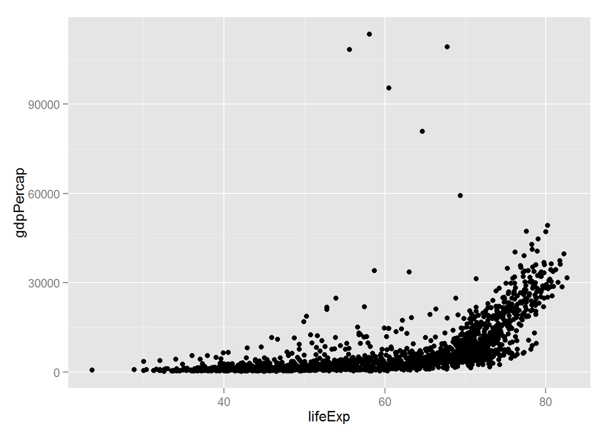

```r
library(ggplot2)
ggplot(data = gapminder, aes(x = lifeExp, y = gdpPercap)) +
  geom_point()
```

We need to tell `ggplot` how we want to visually represent the data, which we do by adding a new **geom** layer. In our example, we used `geom_point`, which tells `ggplot` we want to visually represent the relationship between **x** and **y** as a scatterplot of points:

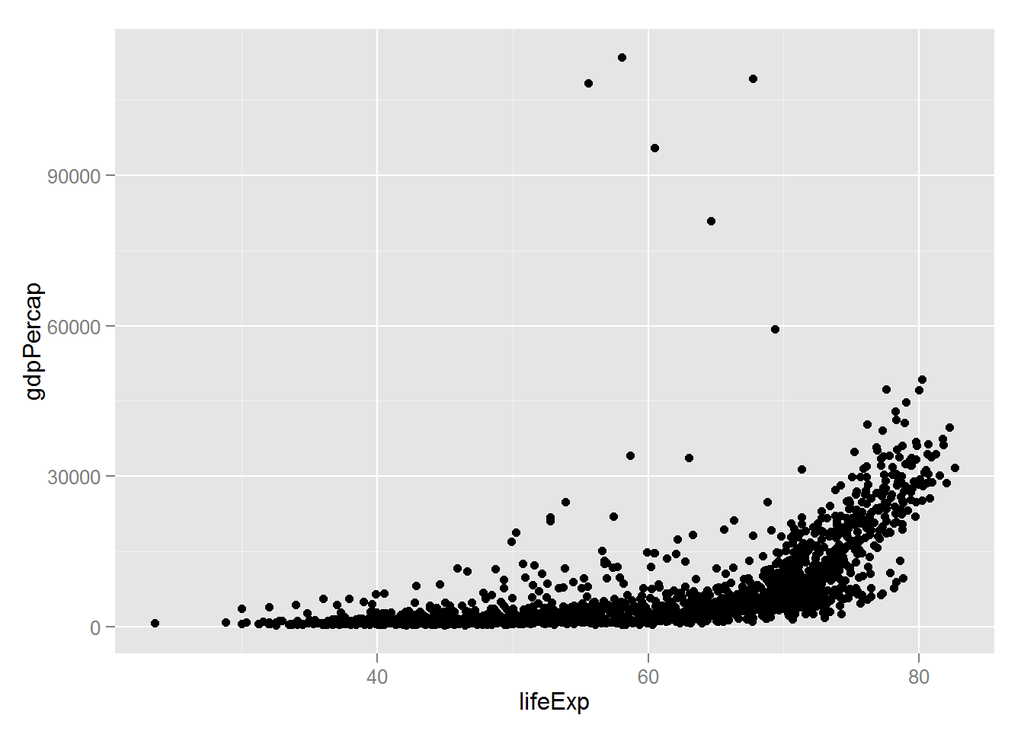

```r
ggplot(data = gapminder, aes(x = lifeExp, y = gdpPercap)) +
  geom_point()
```

#### Challenge 1

> Modify the example so that the figure visualise how life expectancy has changed over time:

> ```r
> ggplot(data = gapminder, aes(x = lifeExp, y = gdpPercap)) + geom_point()
> ```

> Hint: the gapminder dataset has a column called “year”, which should appear on the x-axis.

#### Challenge 2

> In the previous examples and challenge we’ve used the `aes` function to tell the scatterplot **geom** about the **x** and **y** locations of each point. Another *aesthetic* property we can modify is the point *color*. Modify the code from the previous challenge to **color** the points by the “continent” column. What trends do you see in the data? Are they what you expected?

### Layers

Using a scatterplot probably isn’t the best for visualising change over time. Instead, let’s tell `ggplot` to visualise the data as a line plot:

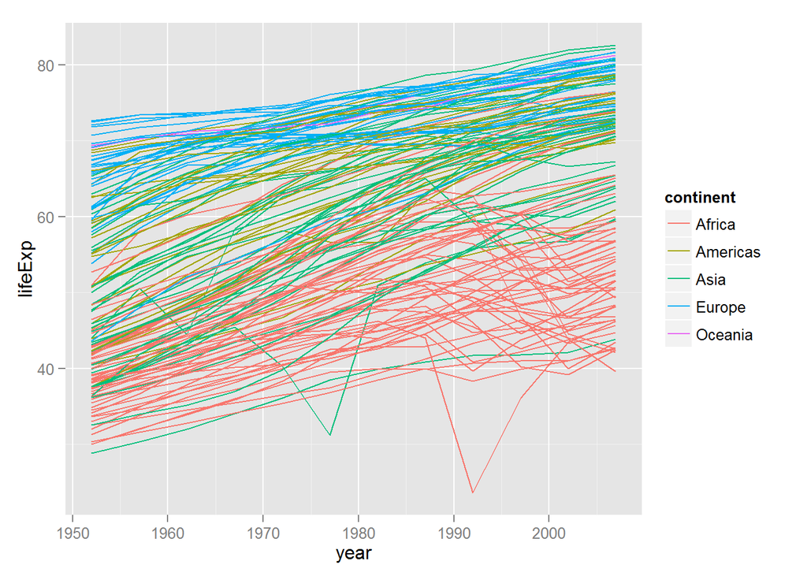

```r
ggplot(data = gapminder, aes(x=year, y=lifeExp, by=country, color=continent)) +
  geom_line()
```

Instead of adding a `geom_point` layer, we’ve added a `geom_line` layer. We’ve added the **by** *aesthetic*, which tells `ggplot` to draw a line for each country.

But what if we want to visualise both lines and points on the plot? We can simply add another layer to the plot:

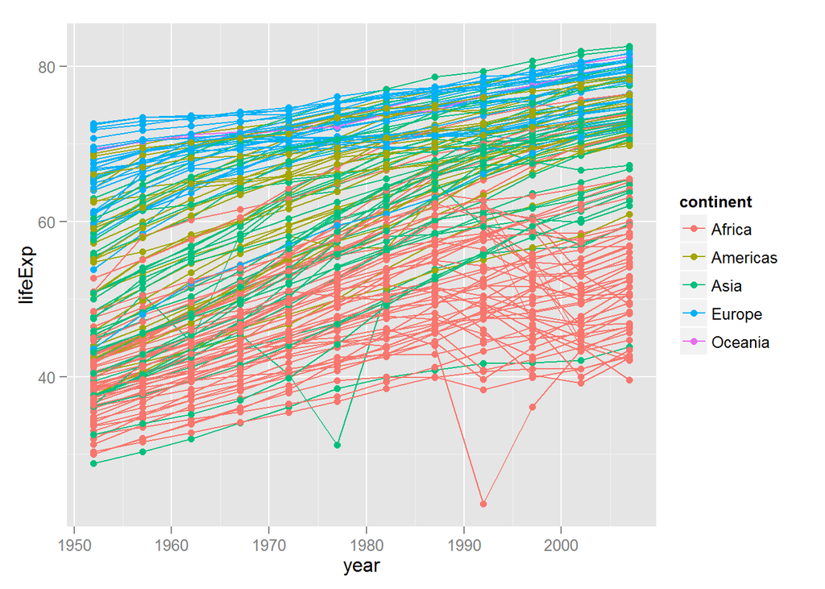

```r
ggplot(data = gapminder, aes(x=year, y=lifeExp, by=country, color=continent)) +
  geom_line() + geom_point()
```

It’s important to note that each layer is drawn on top of the previous layer. In this example, the points have been drawn *on top of* the lines. Here’s a demonstration:

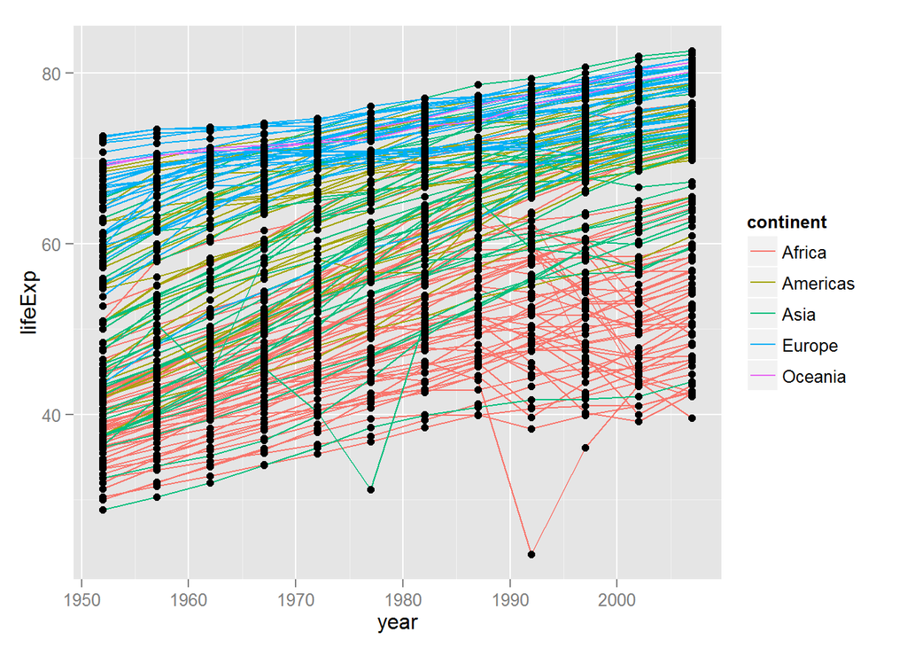

```r
ggplot(data = gapminder, aes(x=year, y=lifeExp, by=country)) +
  geom_line(aes(color=continent)) + geom_point()
```

In this example, the *aesthetic* mapping of **color** has been moved from the global plot options in `ggplot` to the `geom_line` layer so it no longer applies to the points. Now we can clearly see that the points are drawn on top of the lines.

#### Challenge 3

> Switch the order of the point and line layers from the previous example. What happened?

### Transformations and statistics

Ggplot also makes it easy to overlay statistical models over the data. To demonstrate we’ll go back to our first example:

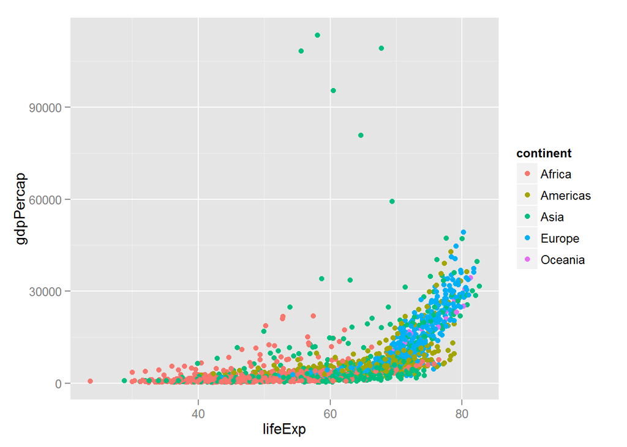

```r
ggplot(data = gapminder, aes(x = lifeExp, y = gdpPercap, color=continent)) +
  geom_point()
```

Currently it’s hard to see the relationship between the points due to some strong outliers in GDP per capita. We can change the scale of units on the y axis using the *scale* functions. These control the mapping between the data values and visual values of an aesthetic.

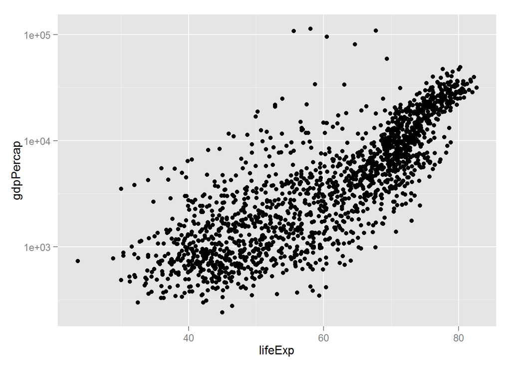

```r
ggplot(data = gapminder, aes(x = lifeExp, y = gdpPercap)) +
  geom_point() + scale_y_log10()
```

The `log10` function applied a transformation to the values of the gdpPercap column before rendering them on the plot, so that each multiple of 10 now only corresponds to an increase in 1 on the transformed scale, e.g. a GDP per capita of 1,000 is now 3 on the y axis, a value of 10,000 corresponds to 4 on the y axis and so on. This makes it easier to visualise the spread of data on the y-axis.

We can fit a simple relationship to the data by adding another layer, `geom_smooth`:

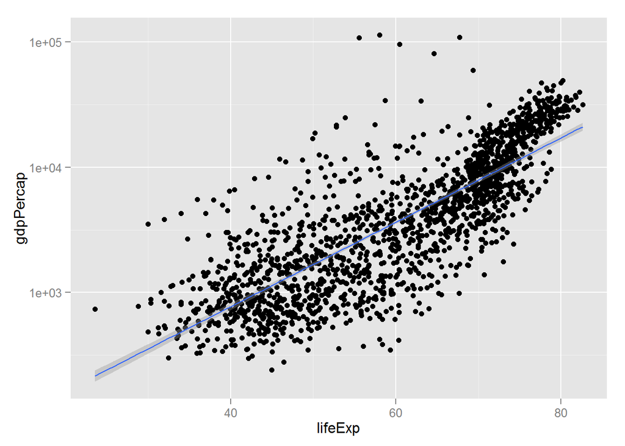

```r
ggplot(data = gapminder, aes(x = lifeExp, y = gdpPercap)) +
  geom_point() + scale_y_log10() + geom_smooth(method="lm")
```

We can make the line thicker by *setting* the **size** aesthetic in the `geom_smooth` layer:

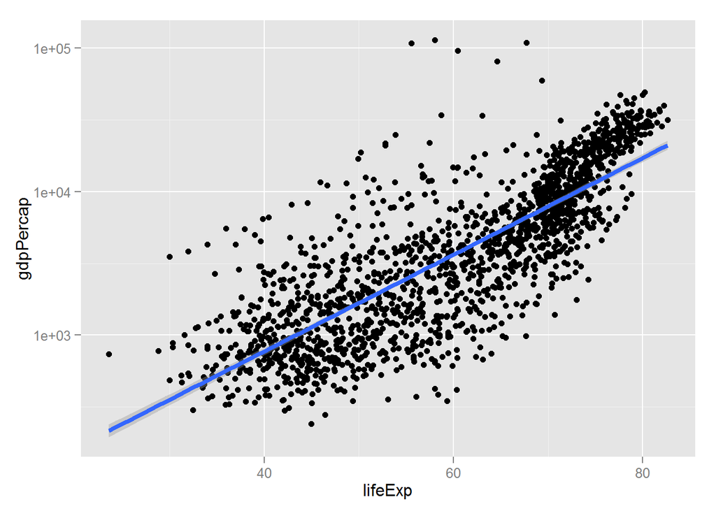

```r
ggplot(data = gapminder, aes(x = lifeExp, y = gdpPercap)) +
  geom_point() + scale_y_log10() + geom_smooth(method="lm", size=1.5)
```

There are two ways an *aesthetic* can be specified. Here we *set* the **size** aesthetic by passing it as an argument to `geom_smooth`. Previously in the lesson we’ve used the `aes` function to define a *mapping* between data variables and their visual representation.

#### Challenge 4

> Modify the color and size of the points on the point layer in the previous example.

> Hint: do not use the `aes` function.

### Multi-panel figures

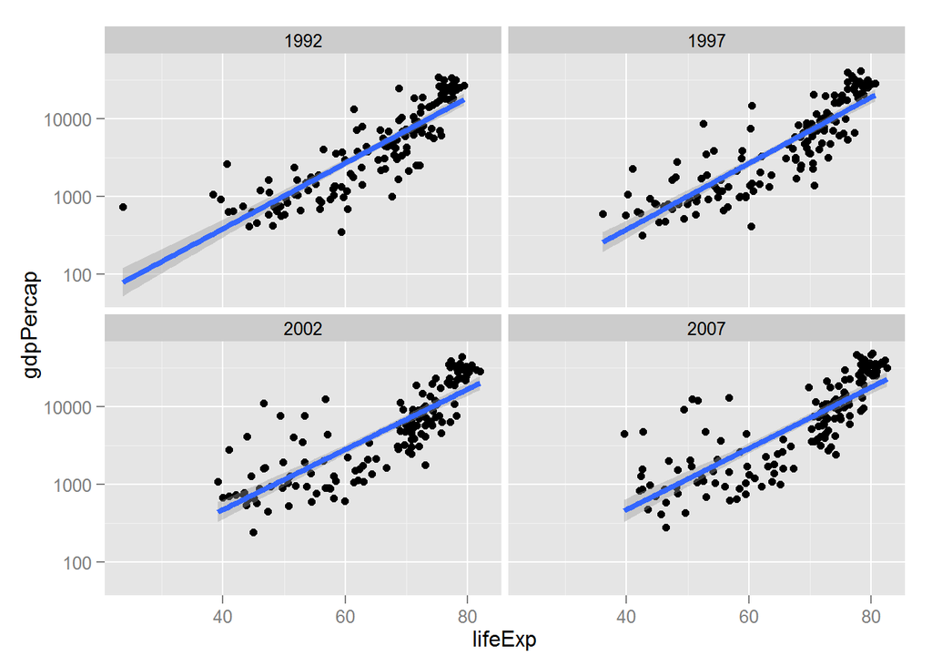

```r
gapminder2 <- gapminder[gapminder$year > 1990,]

ggplot(data = gapminder2, aes(x = lifeExp, y = gdpPercap)) +
  geom_point() + scale_y_log10() + geom_smooth(method="lm", size=1.5) +
  facet_wrap(~ year)
```

### Modifying text

To clean this figure up for a publication we need to change some of the text elements.

We can do this by adding a couple of different layers. The **theme** layer controls the axis text, and overall text size, and there are special layers for changing the axis labels. To change the legend title, we need to use the **scales** layer.

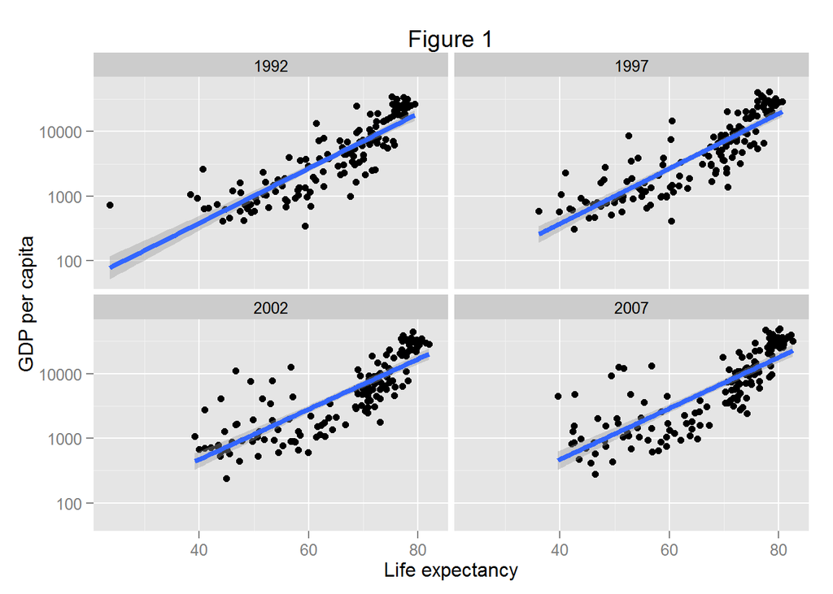

```r
ggplot(data = gapminder2, aes(x = lifeExp, y = gdpPercap)) +
  geom_point() + scale_y_log10() + geom_smooth(method="lm", size=1.5) +
  facet_wrap(~ year) +
  xlab("Life expectancy") + ylab("GDP per capita") + ggtitle("Figure 1")
```

This is just a taste of what you can do with `ggplot2`. RStudio provides a really useful [cheat sheet](http://www.rstudio.com/wp-content/uploads/2015/03/ggplot2-cheatsheet.pdf) of the different layers available, and more extensive documentation is available on the [ggplot2 website](http://docs.ggplot2.org/current/). Finally, if you have no idea how to change something, a quick google search will usually send you to a relevant question and answer on Stack Overflow with reusable code to modify!

#### Challenge 5

> Create a density plot of GDP per capita, filled by continent.

> Advanced: - Transform the x axis to better visualise the data spread. - Add a facet layer to panel the density plots by year.

## Working with data frames

Talk about:

- Adding columns to data frames using calculations

Do a gapminder project that somewhat resembles something you might actually want to do

## From plots to functions -> Project to show why you might want to have functions

e.g. what if you want to repeat an analysis on multiple data sets?

## Functions

If we only had one data set to analyze, it would probably be faster to load the file into a spreadsheet and use that to plot simple statistics. However, the gapminder data is updated periodically, and we may want to pull in that new information later and re-run our analysis again. We may also obtain similar data from a different source in the future.

In this lesson, we’ll learn how to write a function so that we can repeat several operations with a single command.

## What is a function?

> Functions gather a sequence of operations into a whole, preserving it for ongoing use. Functions provide:
> - a name we can remember and invoke it by
> - relief from the need to remember the individual operations
> - a defined set of inputs and expected outputs
> - rich connections to the larger programming environment

> As the basic building block of most programming languages, user-defined functions constitute “programming” as much as any single abstraction can. If you have written a function, you are a computer programmer.

### Defining a function

Let’s open a new R script file in the `functions/` directory and call it functions-lesson.R.

```r
my_sum <- function(a, b) {
  the_sum <- a + b
  return(the_sum)
}
```

Let’s define a function fahr_to_kelvin that converts temperatures from Fahrenheit to Kelvin:

```r
fahr_to_kelvin <- function(temp) {
  kelvin <- ((temp - 32) * (5 / 9)) + 273.15
  return(kelvin)
}
```

We define `fahr_to_kelvin` by assigning it to the output of `function`. The list of argument names are contained within parentheses. Next, the body of the function–the statements that are executed when it runs–is contained within curly braces (`{}`). The statements in the body are indented by two spaces. This makes the code easier to read but does not affect how the code operates.

When we call the function, the values we pass to it are assigned to those variables so that we can use them inside the function. Inside the function, we use a return statement to send a result back to whoever asked for it.

## Tip

> One feature unique to R is that the return statement is not required. R automatically returns whichever variable is on the last line of the body of the function. Since we are just learning, we will explicitly define the return statement.

Let’s try running our function. Calling our own function is no different from calling any other function:

```r
# freezing point of water
fahr_to_kelvin(32)
```

```
[1] 273.15
```

```r
# boiling point of water
fahr_to_kelvin(212)
```

```
[1] 373.15
```

#### Challenge 1

> Write a function called `kelvin_to_celsius` that takes a temperature in Kelvin and returns that temperature in Celsius

> Hint: To convert from Kelvin to Celsius you minus 273.15

#### Combining functions

The real power of functions comes from mixing, matching and combining them into ever large chunks to get the effect we want.

Let’s define two functions that will convert temperature from Fahrenheit to Kelvin, and Kelvin to Celsius:

```r
fahr_to_kelvin <- function(temp) {
  kelvin <- ((temp - 32) * (5 / 9)) + 273.15
  return(kelvin)
}

kelvin_to_celsius <- function(temp) {
  celsius <- temp - 273.15
  return(celsius)
}
```

#### Challenge 2

> Define the function to convert directly from Fahrenheit to Celsius, by reusing the two functions above (or using your own functions if you prefer).

We’re going to define a function that calculates the Gross Domestic Product of a nation from the data available in our dataset:

```r
# Takes a dataset and multiplies the population column
# with the GDP per capita column.
calcGDP <- function(dat) {
  gdp <- dat$pop * dat$gdpPercap
  return(gdp)
}
```

We define `calcGDP` by assigning it to the output of `function`. The list of argument names are contained within parentheses. Next, the body of the function – the statements executed when you call the function – is contained within curly braces (`{}`).

We’ve indented the statements in the body by two spaces. This makes the code easier to read but does not affect how it operates.

When we call the function, the values we pass to it are assigned to the arguments, which become variables inside the body of the function.

Inside the function, we use the `return` function to send back the result. This return function is optional: R will automatically return the results of whatever command is executed on the last line of the function.

```r
calcGDP(head(gapminder))
```

```
[1]  6567086330  7585448670  8758855797  9648014150  9678553274 11697659231
```

That’s not very informative. Let’s add some more arguments so we can extract that per year and country.

```r
# Takes a dataset and multiplies the population column
# with the GDP per capita column.
calcGDP <- function(dat, year=NULL, country=NULL) {
  if(!is.null(year)) {
    dat <- dat[dat$year %in% year, ]
  }
  if (!is.null(country)) {
    dat <- dat[dat$country %in% country,]
  }
  gdp <- dat$pop * dat$gdpPercap

  new <- cbind(dat, gdp=gdp)
  return(new)
}
```

If you’ve been writing these functions down into a separate R script (a good idea!), you can load in the functions into our R session by using the `source` function:

```r
source("functions/functions-lesson.R")
```

Ok, so there’s a lot going on in this function now. In plain English, the function now subsets the provided data by year if the year argument isn’t empty, then subsets the result by country if the country argument isn’t empty. Then it calculates the GDP for whatever subset emerges from the previous two steps. The function then adds the GDP as a new column to the subsetted data and returns this as the final result. You can see that the output is much more informative than just getting a vector of numbers.

Let’s take a look at what happens when we specify the year:

```r
head(calcGDP(gapminder, year=2007))
```

```
       country year      pop continent lifeExp  gdpPercap          gdp
12 Afghanistan 2007 31889923      Asia  43.828   974.5803  31079291949
24     Albania 2007  3600523    Europe  76.423  5937.0295  21376411360
36     Algeria 2007 33333216    Africa  72.301  6223.3675 207444851958
48      Angola 2007 12420476    Africa  42.731  4797.2313  59583895818
60   Argentina 2007 40301927  Americas  75.320 12779.3796 515033625357
72   Australia 2007 20434176   Oceania  81.235 34435.3674 703658358894
```

Or for a specific country:

```r
calcGDP(gapminder, country="Australia")
```

```
     country year      pop continent lifeExp gdpPercap          gdp
61 Australia 1952  8691212   Oceania  69.120  10039.60  87256254102
62 Australia 1957  9712569   Oceania  70.330  10949.65 106349227169
63 Australia 1962 10794968   Oceania  70.930  12217.23 131884573002
64 Australia 1967 11872264   Oceania  71.100  14526.12 172457986742
65 Australia 1972 13177000   Oceania  71.930  16788.63 221223770658
66 Australia 1977 14074100   Oceania  73.490  18334.20 258037329175
67 Australia 1982 15184200   Oceania  74.740  19477.01 295742804309
68 Australia 1987 16257249   Oceania  76.320  21888.89 355853119294
69 Australia 1992 17481977   Oceania  77.560  23424.77 409511234952
70 Australia 1997 18565243   Oceania  78.830  26997.94 501223252921
71 Australia 2002 19546792   Oceania  80.370  30687.75 599847158654
72 Australia 2007 20434176   Oceania  81.235  34435.37 703658358894
```

Or both:

```r
calcGDP(gapminder, year=2007, country="Australia")
```

```
     country year      pop continent lifeExp gdpPercap          gdp
72 Australia 2007 20434176   Oceania  81.235  34435.37 703658358894
```

Let’s walk through the body of the function:

```r
calcGDP <- function(dat, year=NULL, country=NULL) {
```

Here we’ve added two arguments, `year`, and `country`. We’ve set *default arguments* for both as `NULL` using the `=` operator in the function definition. This means that those arguments will take on those values unless the user specifies otherwise.

```r
  if(!is.null(year)) {
    dat <- dat[dat$year %in% year, ]
  }
  if (!is.null(country)) {
    dat <- dat[dat$country %in% country,]
  }
```

Here, we check whether each additional argument is set to `null`, and whenever they’re not `null` overwrite the dataset stored in `dat` with a subset given by the non-`null` argument.

I did this so that our function is more flexible for later. We can ask it to calculate the GDP for:

- The whole dataset;
- A single year;
- A single country;
- A single combination of year and country.

By using `%in%` instead, we can also give multiple years or countries to those arguments.

#### Tip: Pass by value

> Functions in R almost always make copies of the data to operate on inside of a function body. When we modify `dat` inside the function we are modifying the copy of the gapminder dataset stored in `dat`, not the original variable we gave as the first argument.

> This is called “pass-by-value” and it makes writing code much safer: you can always be sure that whatever changes you make within the body of the function, stay inside the body of the function.

#### Tip: Function scope

> Another important concept is scoping: any variables (or functions!) you create or modify inside the body of a function only exist for the lifetime of the function’s execution. When we call `calcGDP`, the variables `dat`, `gdp` and `new` only exist inside the body of the function. Even if we have variables of the same name in our interactive R session, they are not modified in any way when executing a function.

```r
  gdp <- dat$pop * dat$gdpPercap
  new <- cbind(dat, gdp=gdp)
  return(new)
}
```

Finally, we calculated the GDP on our new subset, and created a new data frame with that column added. This means when we call the function later we can see the context for the returned GDP values, which is much better than in our first attempt where we just got a vector of numbers.

#### Challenge 3

> The `paste` function can be used to combine text together, e.g:

> ```r
> best_practice <- c("Write", "programs", "for", "people", "not", "computers")
> paste(best_practice, collapse=" ")
> ```

> ```
> [1] "Write programs for people not computers"
> ```

> Write a function called `fence` that takes two vectors as arguments, called `text` and `wrapper`, and prints out the text wrapped with the `wrapper`:

> ```r
> fence(text=best_practice, wrapper="***")
> ```

> *Note:* the `paste` function has an argument called `sep`, which specifies the separator between text. The default is a space: " “. The default for `paste0` is no space”“.

## Tip

> R has some unique aspects that can be exploited when performing more complicated operations. We will not be writing anything that requires knowledge of these more advanced concepts. In the future when you are comfortable writing functions in R, you can learn more by reading the [R Language Manual](http://cran.r-project.org/doc/manuals/r-release/R-lang.html#Environment-objects) or this [chapter](http://adv-r.had.co.nz/Environments.html) from [Advanced R Programming](http://adv-r.had.co.nz/) by Hadley Wickham. For context, R uses the terminology “environments” instead of frames.

#### Tip: Testing and documenting

> It’s important to both test functions and document them: Documentation helps you, and others, understand what the purpose of your function is, and how to use it, and its important to make sure that your function actually does what you think.

> When you first start out, your workflow will probably look a lot like this:
> 1. Write a function
> 2. Comment parts of the function to document its behaviour
> 3. Load in the source file
> 4. Experiment with it in the console to make sure it behaves as you expect
> 5. Make any necessary bug fixes
> 6. Rinse and repeat.

> Formal documentation for functions, written in separate `.Rd` files, gets turned into the documentation you see in help files. The [roxygen2](http://cran.r-project.org/web/packages/roxygen2/vignettes/rd.html) package allows R coders to write documentation alongside the function code and then process it into the appropriate `.Rd` files. You will want to switch to this more formal method of writing documentation when you start writing more complicated R projects.

> Formal automated tests can be written using the [testthat](http://r-pkgs.had.co.nz/tests.html) package.

## Challenge solutions

#### Solution to challenge 1

> Write a function called `kelvin_to_celsius` that takes a temperature in Kelvin and returns that temperature in Celsius

> ```r
> kelvin_to_celsius <- function(temp) {
>  celsius <- temp - 273.15
>  return(celsius)
> }
> ```

#### Solution to challenge 2

> Define the function to convert directly from Fahrenheit to Celsius, by reusing these two functions above

> ```r
> fahr_to_celsius <- function(temp) {
>   temp_k <- fahr_to_kelvin(temp)
>   result <- kelvin_to_celsius(temp_k)
>   return(result)
> }
> ```

#### Solution to challenge 3

> Write a function called `fence` that takes two vectors as arguments, called `text` and `wrapper`, and prints out the text wrapped with the `wrapper`:

> ```r
> fence <- function(text, wrapper){
>   text <- c(wrapper, text, wrapper)
>   result <- paste(text, collapse = " ")
>   return(result)
> }
> best_practice <- c("Write", "programs", "for", "people", "not", "computers")
> fence(text=best_practice, wrapper="***")
> ```

> ```
> [1] "*** Write programs for people not computers ***"
> ```